# Regression Evaluation

Jack Rossi

May 29th 2017

As a follow up to the previous classification problem evaluation, I want to extend the analysis to be able to address the question: “given a level of accuracy, how far in advance can we expect to know about a coming surge?” I will attempt this through a couple of methods: By systematically visualizing our surge predictions in comparison to the actual historical records in our test data; and by developing measures to address this question, for example the average time difference between a forecast indicating surge and the actual onset of surge. If these methods prove to be insufficient, I can move on to development of Activity monitoring ROC curves, an evaluation preferred by Hoot et al.

```r
testdata$PredOcc_2hr <- NA

#loop through the unique days in the data - two inner loops will first find max OccRate in a day, and then #fill in the OccRate predictions based on the location and value of that maximum
for (m in min(testdata$dday):max(testdata$dday)){
  #and through each data point contained in those days
  for (n in which(testdata$dday == m)){
    #do nothing to the first 22 data points in the data set: else the equation below would throw an error
    if (n < 23){

    }
    else if(testdata$OccRate[n] == max(testdata$OccRate[testdata$dday==m])){
      testdata$PredOcc_2hr[n-11] <- testdata$OccRate[n-11]
      break
    }
  }
  for (n in which(testdata$dday == m)){
    if (n == 1){
    ##do nothing
    }
    else if((!is.na(testdata$PredOcc_2hr[n-1])) & testdata$dday[n-1] == testdata$dday[n]){
    testdata$PredOcc_2hr[n] <- testdata$PredOcc_2hr[n-1] +
      delta$dOcc[delta$wkday == testdata$wkday[n-1] &
                 as.POSIXlt(delta$Time)$hour == testdata$hr[n-1] &
                 as.POSIXlt(delta$Time)$min == testdata$min[n-1]]
    }
  }

}
```

```r
testdata$PredFCOcc_1hr <- NA

#loop through the unique days in the data - two inner loops will first find max OccRate in a day, and then #fill in the OccRate predictions based on the location and value of that maximum
for (m in min(testdata$dday):max(testdata$dday)){
  #and through each data point contained in those days
  for (n in which(testdata$dday == m)){
    #do nothing to the first 11 data points in the data set: else the equation below would throw an error
    if (n < 6){

    }
    else if(testdata$OccRate[n] == max(testdata$OccRate[testdata$dday==m])){
      testdata$PredFCOcc_1hr[n-5] <- testdata$FCOccRate[n-5]
      break
    }
  }
  for (n in which(testdata$dday == m)){
    if (n == 1){
    ##do nothing
    }
    else if(!is.na(testdata$PredFCOcc_1hr[n-1]) & testdata$dday[n-1] == testdata$dday[n]){
    testdata$PredFCOcc_1hr[n] <- testdata$PredFCOcc_1hr[n-1] +
                                  delta$dFCOcc[delta$wkday == testdata$wkday[n-1] &
                                        as.POSIXlt(delta$Time)$hour == testdata$hr[n-1] &
                                        as.POSIXlt(delta$Time)$min == testdata$min[n-1]]
    }
  }

}
```

```r
testdata$PredFCOcc_2hr <- NA

#loop through the unique days in the data - two inner loops will first find max OccRate in a day, and then #fill in the OccRate predictions based on the location and value of that maximum
for (m in min(testdata$dday):max(testdata$dday)){
  #and through each data point contained in those days
  for (n in which(testdata$dday == m)){
    #do nothing to the first 22 data points in the data set: else the equation below would throw an error
    if (n < 12){

    }
    else if(testdata$OccRate[n] == max(testdata$OccRate[testdata$dday==m])){
      testdata$PredFCOcc_2hr[n-11] <- testdata$FCOccRate[n-11]
      break
    }
  }
  for (n in which(testdata$dday == m)){
    if (n == 1){
    ##do nothing
    }
    else if((!is.na(testdata$PredFCOcc_2hr[n-1])) & testdata$dday[n-1] == testdata$dday[n]){
    testdata$PredFCOcc_2hr[n] <- testdata$PredFCOcc_2hr[n-1] +
      delta$dFCOcc[delta$wkday == testdata$wkday[n-1] &
                 as.POSIXlt(delta$Time)$hour == testdata$hr[n-1] &
                 as.POSIXlt(delta$Time)$min == testdata$min[n-1]]
    }
  }

}
```

A plot was created for each day in the test data, showing the progression of Occupancy Readings versus the supposed progression as captured by our forecast. Additional examples of these plots are listed in the appendix. I will highlight a few that are representative of the group.

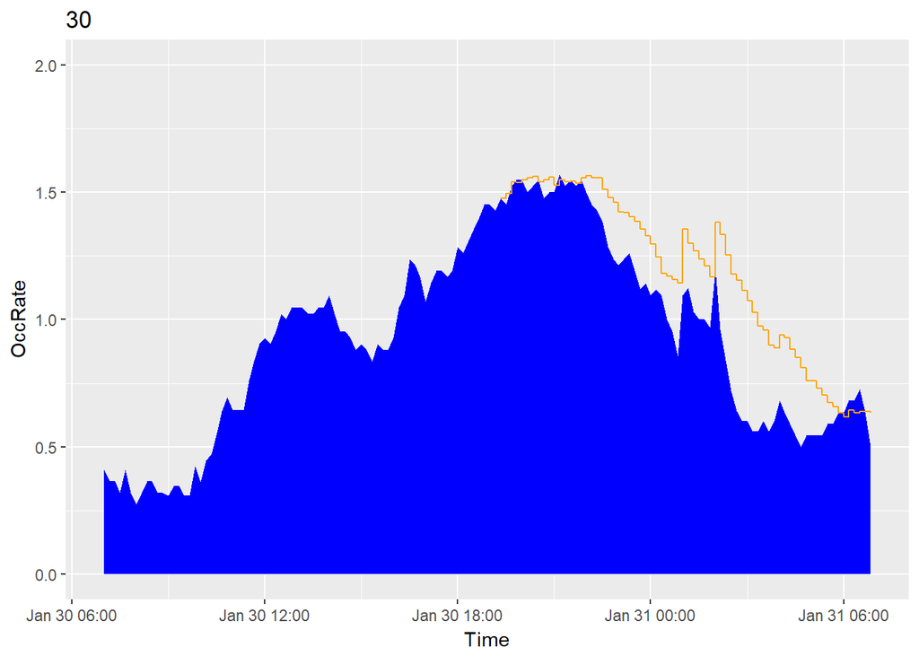

```r
plots = list()
positives = unique(testdata$dday[testdata$OccRate >= 1.50])
for (b in positives ){
   plots[[b]] = ggplot(testdata[testdata$dday == b,], aes(Time, OccRate)) +
     geom_area(fill =   "blue")  +
     geom_step(aes(Time, PredOcc_2hr), na.rm = TRUE, color = "orange")+ ylim(0, 2.0) + ggtitle(b)

}

neg_plots = list()
negatives = setdiff(unique(testdata$dday), positives)
for (a in negatives){
   neg_plots[[a]] = ggplot(testdata[testdata$dday == a,], aes(Time, OccRate)) +
     geom_area(fill =   "blue")  +
     geom_step(aes(Time, PredOcc_2hr), na.rm = TRUE, color = "orange")+ ylim(0, 1.6) + ggtitle(b)

}


plots[[30]] #example of ideal
```

This first plot gives the ideal relation between the forecasted and actual time series. As the shaded blue area shows, the Occupancy of the ED progresses through the day in a relatively smooth, inverted U shape. At about 19:00, two hours before the true maximum, the progression is forecasted in orange, and as it proceeds past 20:00, it accurately projects the time at which the ED will reach Surge status. Unfortunately, very few of the forecasts are this clean. Worse, several of the plots reveal 3 key issues with our current modelling procedure.

```
## geom_path: Each group consists of only one observation. Do you need to
## adjust the group aesthetic?
```

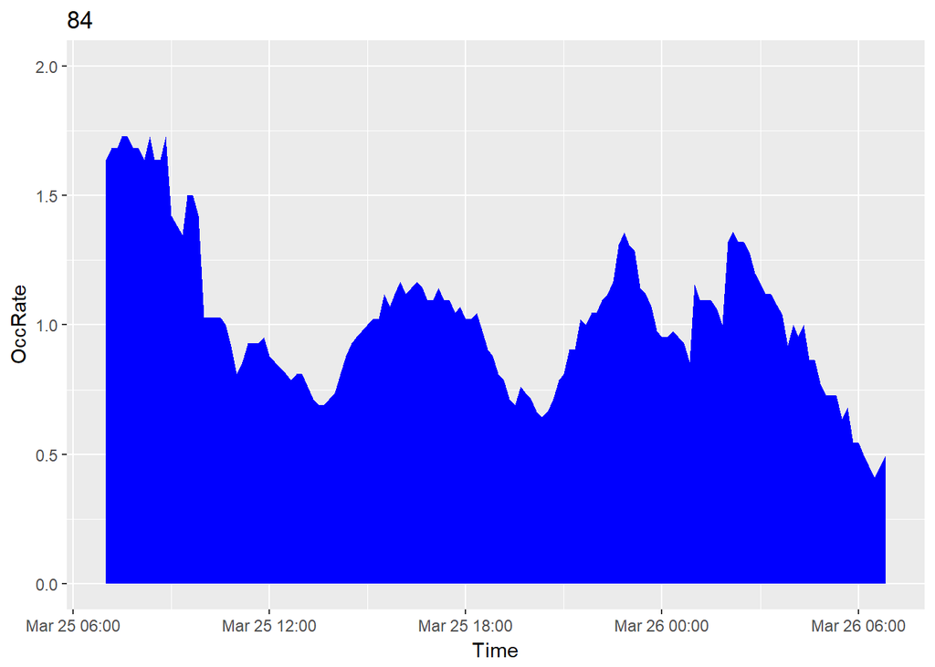

```r
plots[[84]] #example of late night surge carry-over
```

The 84th day of the year shows a characteristically unpredictable Occupancy progression, as well as a commom problem with forecasting for the daily maximum; As a whole, March 25th into the 26th was a slow day. We should be forecasting for the peak that occurs around Mar 25 22:00, but my model identifies the true maximum as a remnant from the previous day (a surge was called), and ceases to make a redundant forecast.

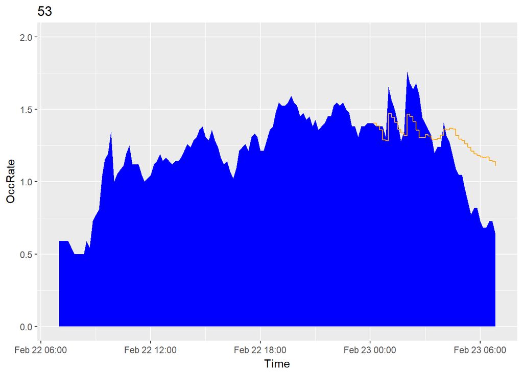

```r
plots[[53]] #example of redundant maximum
```

The 53rd day of the year shows another problem with forecasting for the maximum: In this case and in several others, the timing of the maximum occupancy is a moot point, since the ED already achieved Surge status about 6 hours earlier, around 19:00. To fix this problem, we should forecast for the daily maximum, OR the first daily instance of Occupancy over 1.50, whichever comes first.

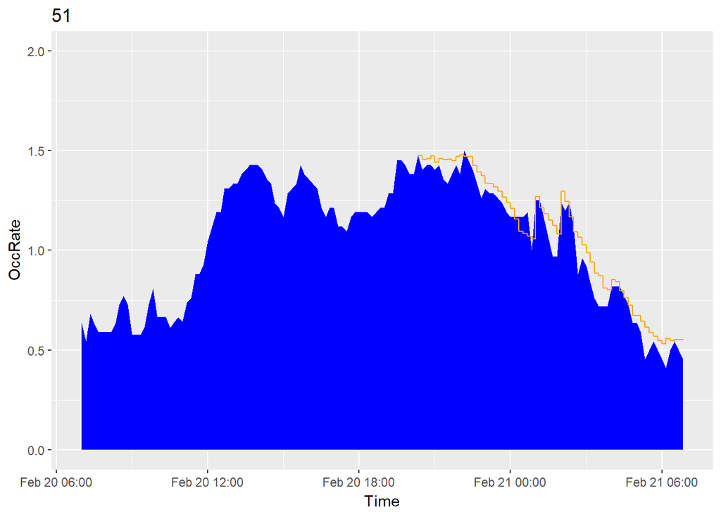

```r
plots[[51]] #example of same-day, distinct surge risks
```

This day of data suggests we should perhaps go further. I should note that in this case we accurately forecast that the daily maximum will approach, though not exceed, our threshold of 1.50. However, it appears that we have neglected a serious and distinct surge threat that occurred earlier in the day, as the rapid filling of the ED around noon shows.

First, I propose that we look for Surge threats only in the hours between 12 noon and the following 7am. I believe this timing captures the onset of most, if not all Surge events. From an operational standpoint, I also believe that we should not have the Clinical Lead initiating huddles in off-peak hours. This change should eliminate the surge carry-over problem.

Next, I would like to forecast for the earliest of either the maximum occupancy rate, or the first instance of Occupancy above 1.50. This should be a relatively simple fix to the problem of the redundant maximum.

Finally, I believe we need a more complex solution to the problem of same-day, distinct surge threats. First, we break down the surge window (12p-7a) into 2-hour intervals, in which we consider whether the maximum occupancy will exceed 1.50. Each interval in which it doesn’t is classified as a Non-surge, and becomes its own data point in our ROC analysis. If the two hour block does, it and the next three blocks will be considered a single surge event, and it too will become a data point in our ROC analysis. The average Surge activation in February and March was 7.013 hours. I chose to round this up to 8 so that it is divisible by 2.

In the following, I will develop the logic to achieve these fixes. I will then repeat the previous plotting to identify any further problems, and finish the analysis with revised ROC plots.

```r
testdata$block = NA

#make blocks
for (k in which(testdata$hr %in% c(12,13,14,15,16,17,18,19,20,21,22,23,0,1,2,3,4,5,6))){
  testdata$block[k] <- paste(testdata$dday[k], testdata$hr[k]-testdata$hr[k]%%2)
}

#modify blocks
blocks = unique(testdata$block)
for (j in 2:length(blocks))
{
  if (max(testdata$OccRate[testdata$block == blocks[j]], na.rm= TRUE) >= 1.50){

    inc = 1 #increment
    while(substr(blocks[j+inc], 4, 5) != "12" & inc <= 3)
    {
      testdata$block[testdata$block == blocks[j+inc]] <- blocks[j]
      inc = inc + 1
    }
  }
}

#check
blockplots = list()
days = unique(testdata$dday)
for (b in days){
   blockplots[[b]] = ggplot(testdata[testdata$dday == b,], aes(Time, OccRate)) +
     geom_area(fill =   "blue")  + facet_wrap(~block) + theme(axis.text.x = element_blank())
}
```

A visual of the blocking of the data is shown in an appendix. Having the data separated as such, we then want to reapply the forecast. The following code will develop this extended forecast, and a visualization of the results will follow.

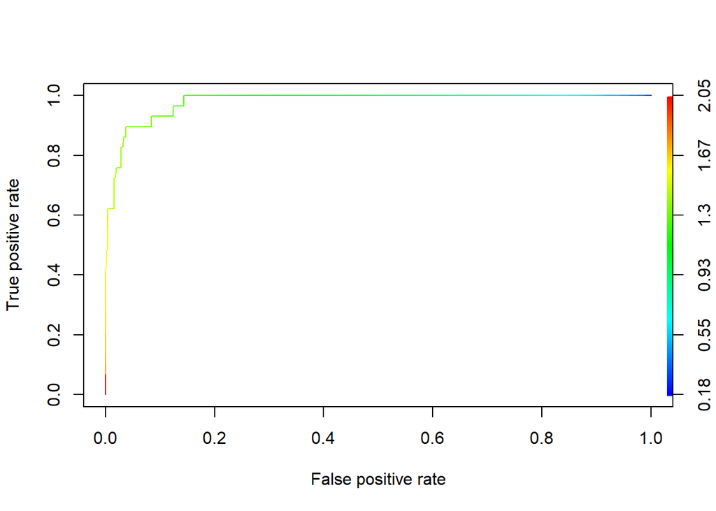

```r
testdata$PredOcc_2hr <- NA


#cycle through each time block
for (m in unique(testdata$block[!is.na(testdata$block)])){
  #establish conditional for contents of time block, for brevity
  condition = testdata$block == m & !is.na(testdata$block)
  #if this block contains first surge or daily maximum
  for (n in which(condition)){
    if (n == min(which(condition))){
      testdata$PredOcc_2hr[n] <- testdata$OccRate[n]
    }
    else{
      testdata$PredOcc_2hr[n] <- testdata$PredOcc_2hr[n-1] +
      delta$dOcc[delta$wkday == testdata$wkday[n-1] &
                 as.POSIXlt(delta$Time)$hour == testdata$hr[n-1] &
                 as.POSIXlt(delta$Time)$min == testdata$min[n-1]]
    }
  }
}

plots12 = list()
for (a in unique(testdata$dday)){
   plots12[[a]] = ggplot(testdata[testdata$dday == a,], aes(Time, OccRate)) +
     geom_area(fill =   "blue")  +
     geom_step(aes(Time, PredOcc_2hr), na.rm = TRUE, color = "orange") +
     facet_wrap(~block) + theme(axis.text.x = element_blank())
}

labs = ddply(testdata[!is.na(testdata$block),], ~block, function(x) c(Surge = length(unique(x$dday[x$OccRate >= 1.50]))))
preds =  ddply(testdata[!is.na(testdata$block),], ~block, function(x) c(max_Occ = max(x$PredOcc_2hr, na.rm = TRUE)))
pred_obj <- prediction(predictions = preds[,"max_Occ"], labels = labs[, "Surge"])
perf <- performance(pred_obj, measure = "tpr", x.measure = "fpr")
plot(perf, colorize =  TRUE)
```

```r
slot(performance(pred_obj, measure = "auc"), "y.values")[[1]]
```

```
## [1] 0.9804649
```

```r
thresh12 <- data.frame("Thresholds" = slot(perf, "alpha.values")[[1]], "FPR" =
                       slot(perf, "x.values")[[1]], "TPR" = slot(perf, "y.values")[[1]])


num_negs <- length(labs$Surge) - sum(labs$Surge)
thresh12$norm_fpr <- thresh12$FPR * num_negs /(length(unique(testdata$dday))/7)
thresh12$Calls_Per_Week <- (thresh12$FPR * num_negs + thresh12$TPR *
                              sum(labs$Surge)) / (length(unique(testdata$dday))/7)

diffs <- ddply(testdata[!is.na(testdata$block),], ~block, function(x) c(diff = difftime(x$Time[x$OccRate >= 1.50][1], x$Time[1], unit = "min")))

pred_diffs <- diffs[preds$max_Occ >= 1.366,]
mean(pred_diffs$diff, na.rm = TRUE)
```

```
## Time difference of 51.15385 mins
```

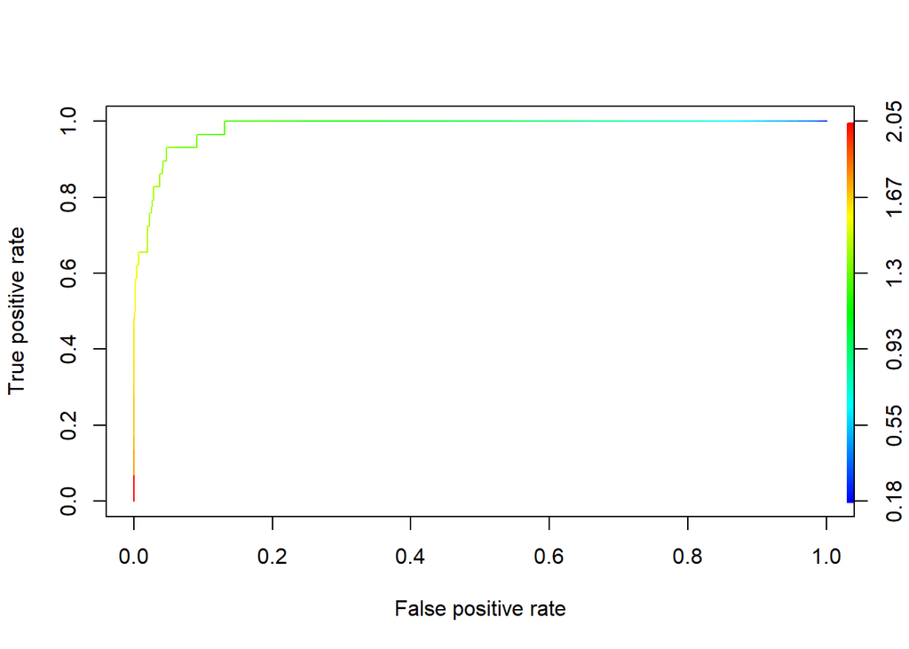

```r
testdata$PredFCOcc_2hr <- NA


#cycle through each time block
for (m in unique(testdata$block[!is.na(testdata$block)])){
  #establish conditional for contents of time block, for brevity
  condition = testdata$block == m & !is.na(testdata$block)
  #for all times in this block
  for (n in which(condition)){
    #if this is the first time
    if (n == min(which(condition))){
      #the prediction is the current FC Occupancy
      testdata$PredFCOcc_2hr[n] <- testdata$FCOccRate[n]
    }
    else{
      testdata$PredFCOcc_2hr[n] <- testdata$PredFCOcc_2hr[n-1] +
      delta$dFCOcc[delta$wkday == testdata$wkday[n-1] &
                 as.POSIXlt(delta$Time)$hour == testdata$hr[n-1] &
                 as.POSIXlt(delta$Time)$min == testdata$min[n-1]]
    }
  }
}

plots18 = list()
for (a in unique(testdata$dday)){
   plots18[[a]] = ggplot(testdata[testdata$dday == a,], aes(Time, OccRate)) +
     geom_area(fill =   "blue")  +
     geom_step(aes(Time, PredOcc_2hr), na.rm = TRUE, color = "orange") +
     facet_wrap(~block) + theme(axis.text.x = element_blank())
}

labs = ddply(testdata[!is.na(testdata$block),], ~block, function(x) c(Surge = length(unique(x$dday[x$OccRate >= 1.50]))))
preds =  ddply(testdata[!is.na(testdata$block),], ~block, function(x) c(max_FCOcc = max(x$PredFCOcc_2hr, na.rm = TRUE)))
pred_obj <- prediction(predictions = preds[,"max_FCOcc"], labels = labs[, "Surge"])
perf <- performance(pred_obj, measure = "tpr", x.measure = "fpr")
plot(perf, colorize =  TRUE)
```

```r
slot(performance(pred_obj, measure = "auc"), "y.values")[[1]]
```

```
## [1] 0.9834467
```

```r
thresh18 <- data.frame("Thresholds" = slot(perf, "alpha.values")[[1]], "FPR" =
                       slot(perf, "x.values")[[1]], "TPR" = slot(perf, "y.values")[[1]])

num_negs <- length(labs$Surge) - sum(labs$Surge)
thresh18$norm_fpr <- thresh18$FPR * num_negs /(length(unique(testdata$dday))/7)
thresh18$Calls_Per_Week <- (thresh18$FPR * num_negs + thresh18$TPR *
                              sum(labs$Surge)) / (length(unique(testdata$dday))/7)

diffs <- ddply(testdata[!is.na(testdata$block),], ~block, function(x) c(diff = difftime(x$Time[x$OccRate >= 1.50][1], x$Time[1], unit = "min")))

pred_diffs <- diffs[preds$max_FCOcc >= 1.366,]
mean(pred_diffs$diff, na.rm = TRUE)
```

```
## Time difference of 51.48148 mins
```

As we saw in a previous update, the results for using Forecasted Occupancy Rate as a predictor fare even better. Though the distribution of FC Occ differs from normal Occupancy, 1.366 is again my choice for threshold. At this level, we would expect to have an FPR of .0466 and a TPR of .931; We also call in the Surge team 51.5 minutes before a Surge on average.

This work represents an improved, if yet imperfect model of a possible implementation of Surge prediction. In practice, the blocking of Time would rarely occur at perfect 2 hour intervals. Though I do not expect this complication to change our results much, it is still one limitation of the model.

## Update: Normalized FPR and Threshold Decision

In order to refine the decision-making of surge threshold, I normalized the False Positive Rate by week. This changes the picture of performance at a 1.366 threshold greatly. This threshold would translate to nearly 3 false positives per week! When viewing FPR in this fashion, it seems more important to limit these cost drivers than to assure that we catch all Surges early - Surges that we don’t catch early are the same as if we had kept the old system.

In my opinion, this revelation changes the best option to Forecast 12+ (changing from the Modified Occupancy to now the normal Occupancy) and a threshold of 1.414. So, if at any time the Unit Clerk makes a forecast, and the tool returns a value of 1.414 or greater, the Surge team should be called immediately. Using the tool this way will give 48.6 minutes of advanced notice on average, catching 72% of Surges early. I chose this threshold by fixing the normalized FPR at 1 per week, which I assumed to be the maximum allowable rate. If 1 per week seems high, consider that this is inlcuded in the overall Surge call rate of 3.56 per week. In 2017 the actual number of call-ins over this time period was 16, a rate of 2.0740741. Also consider that a ‘false alarm’ needn’t be a superfluous activation; conditions in the ED at Occupancy 1.45 are hardly less worthy of additional help than at Occupancy 1.50.

More than likely, the decision of this threshold can be best made by the ED leadership team. The information provided here should be sufficient for a purely statistical perspective. I believe there to be further opportunity to enrich this decision process through simulation analyses, particularly looking at the cost of call-ins versus the benefit of earlier Surge MD action, perhaps as a function of patient waiting time.

## Appendix: Initial Forecast Plots

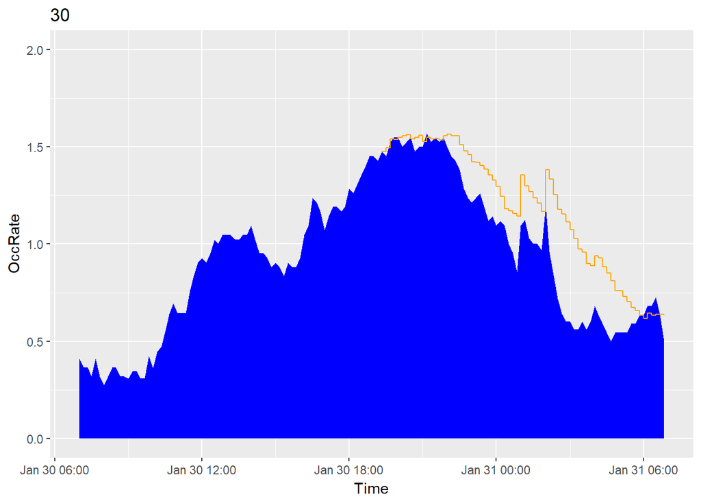

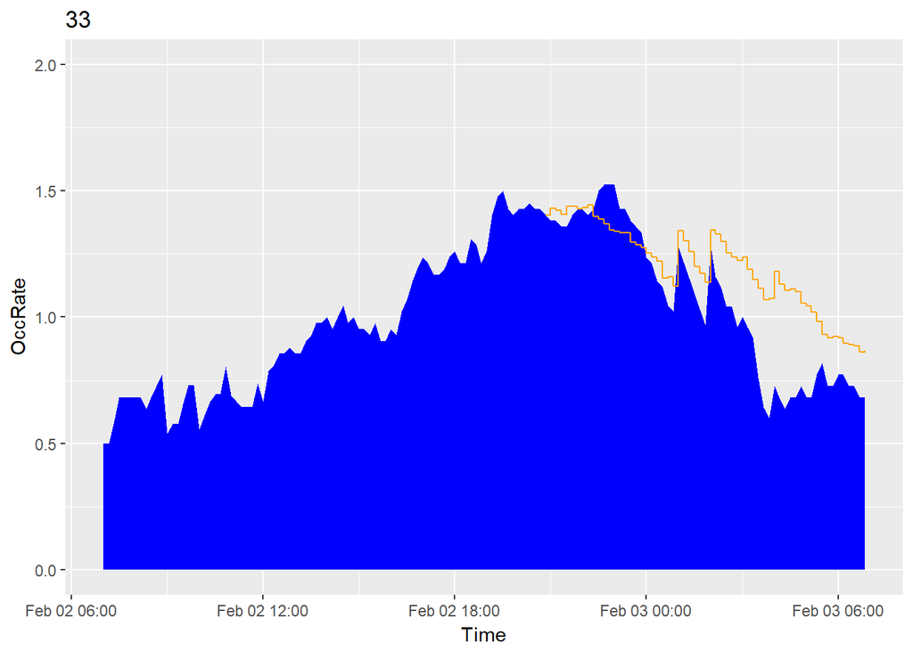

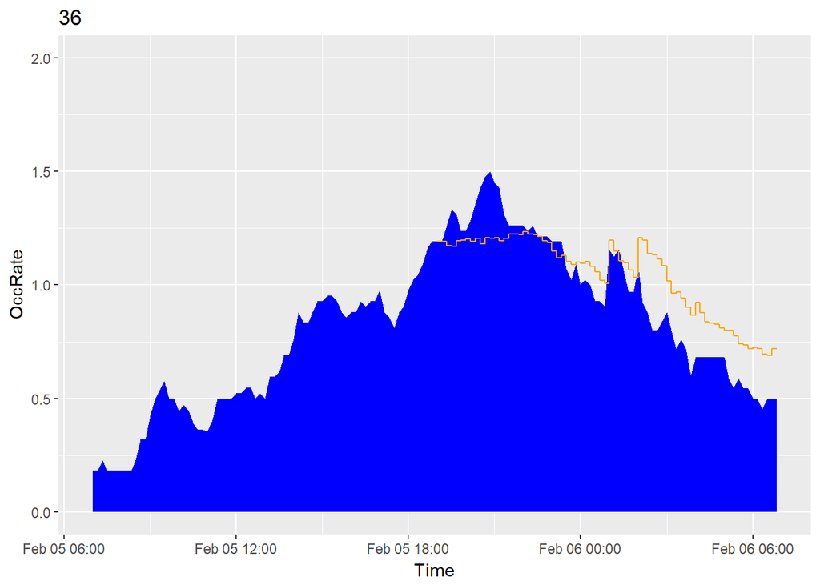

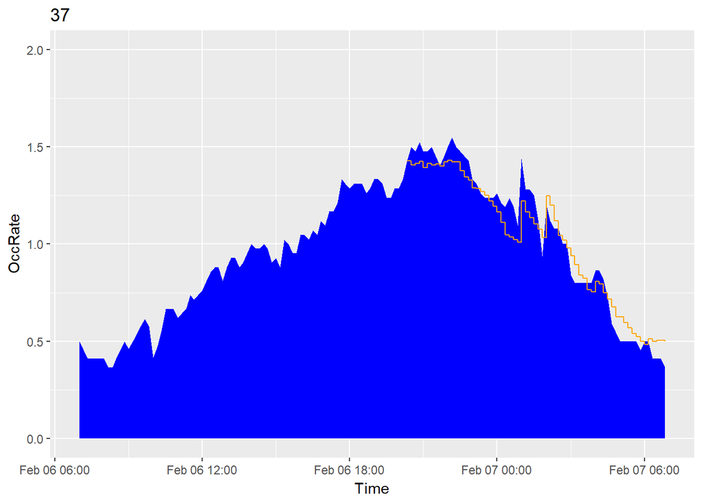

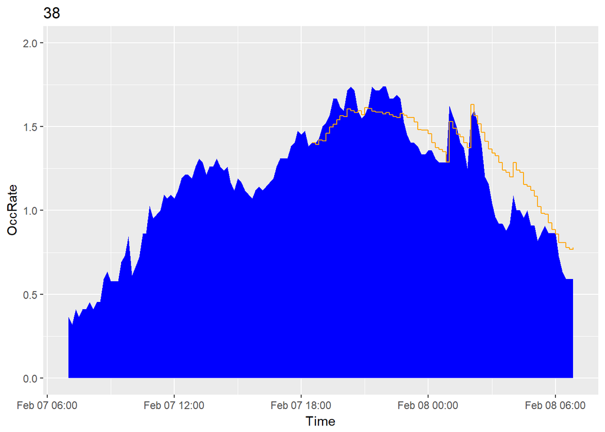

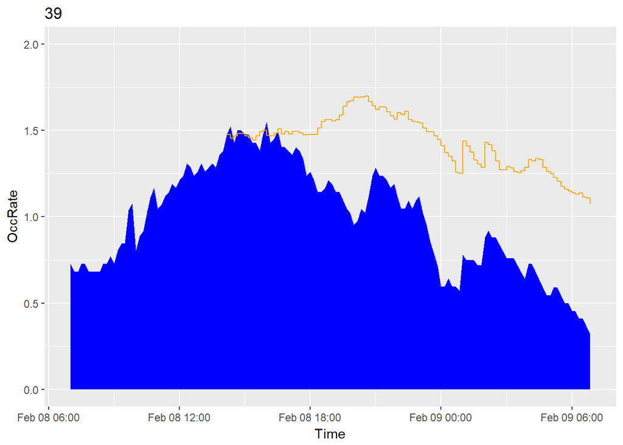

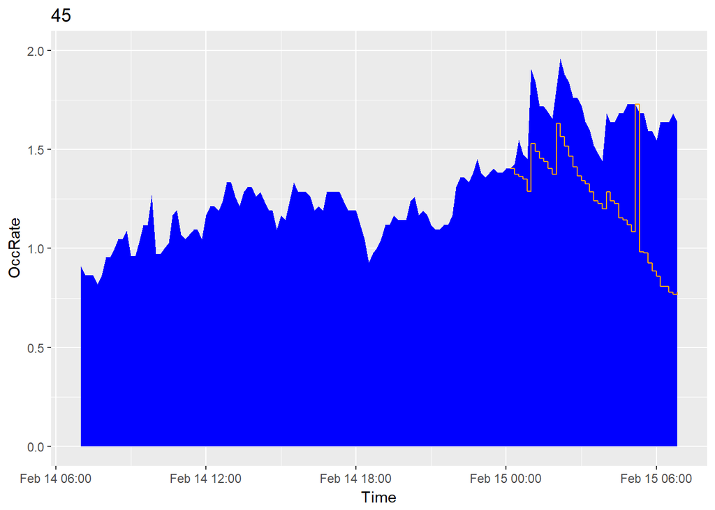

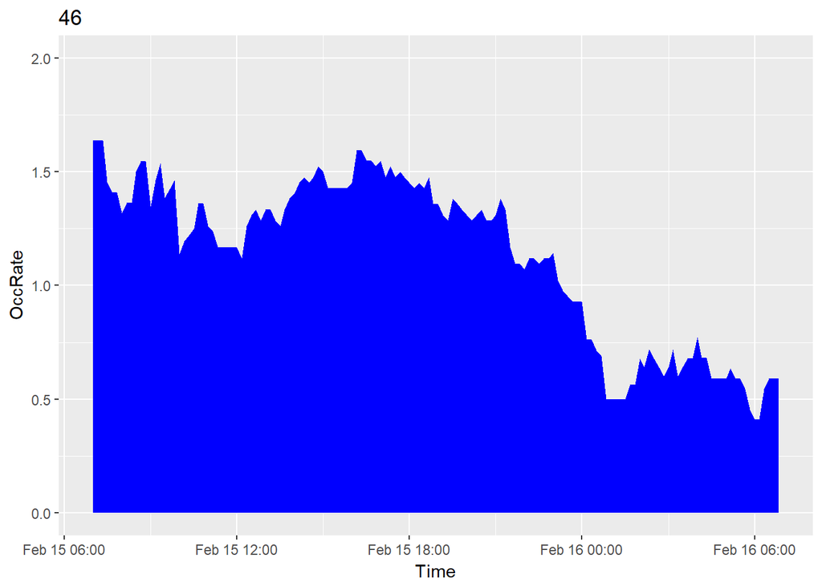

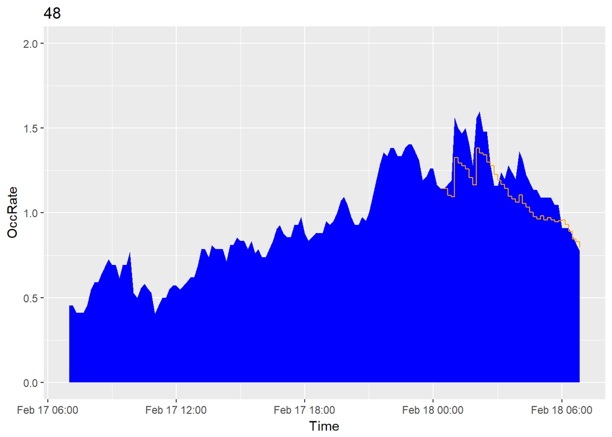

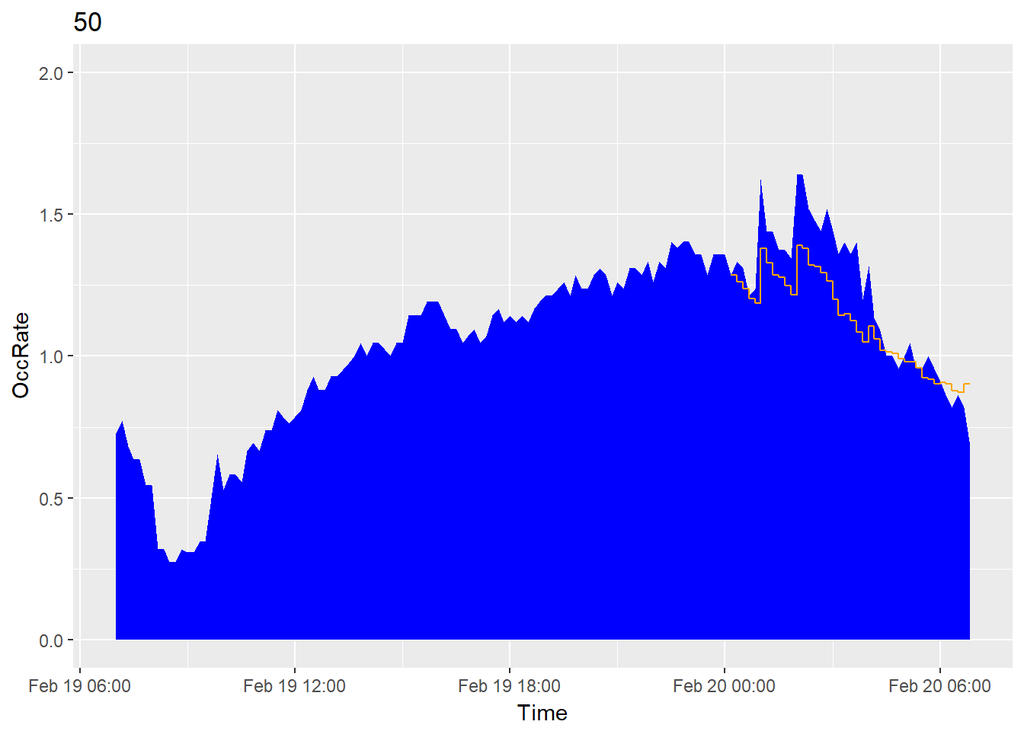

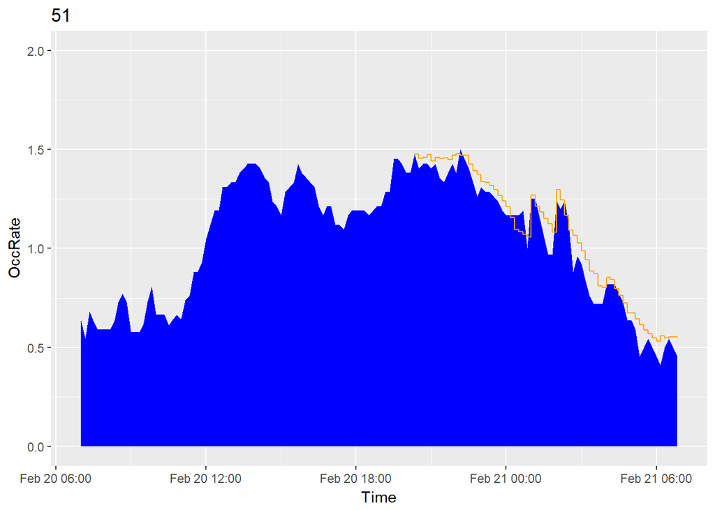

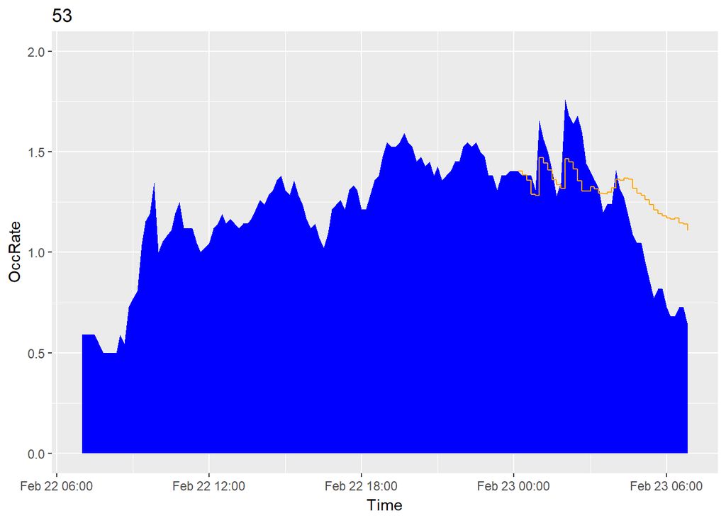

[11 more figures not shown]

```r
plots[positives]
```

# Appendix: Arrangement of Blocks

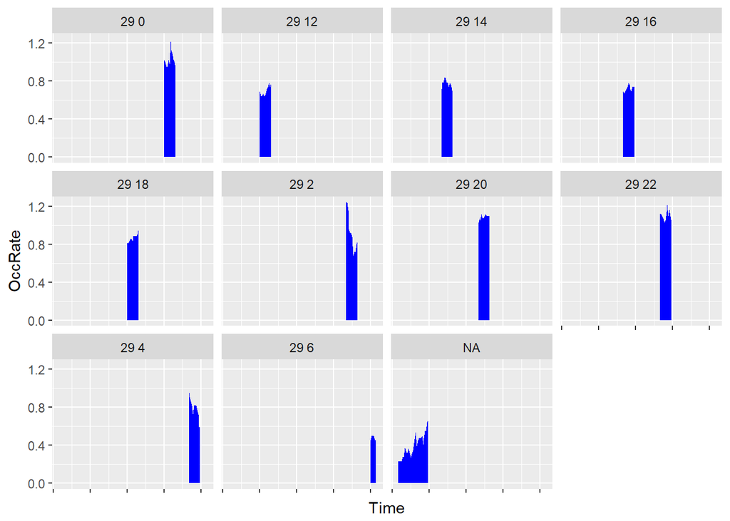

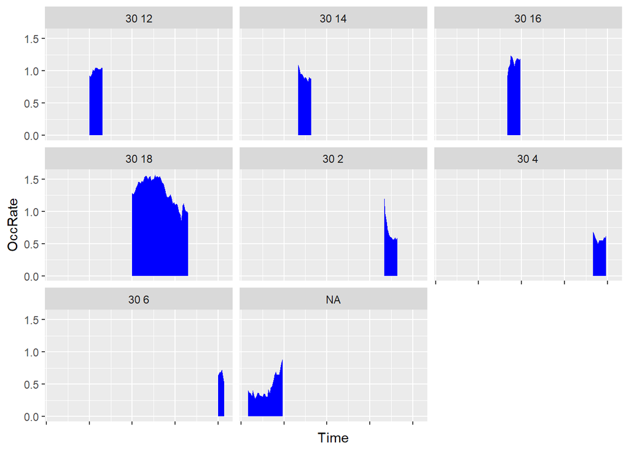

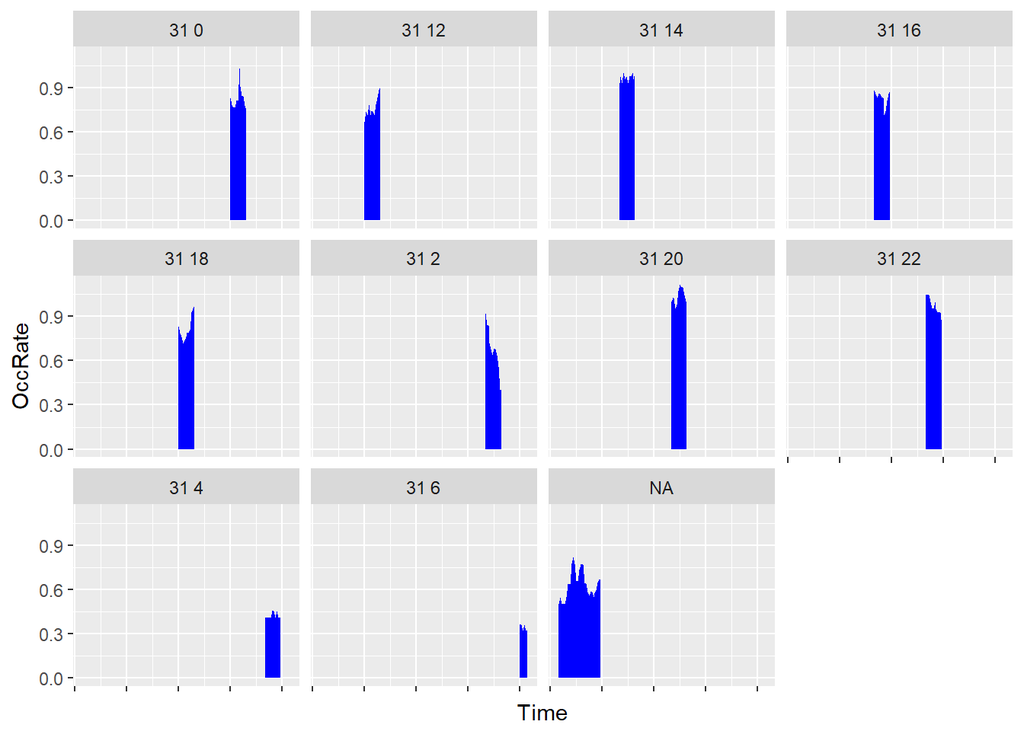

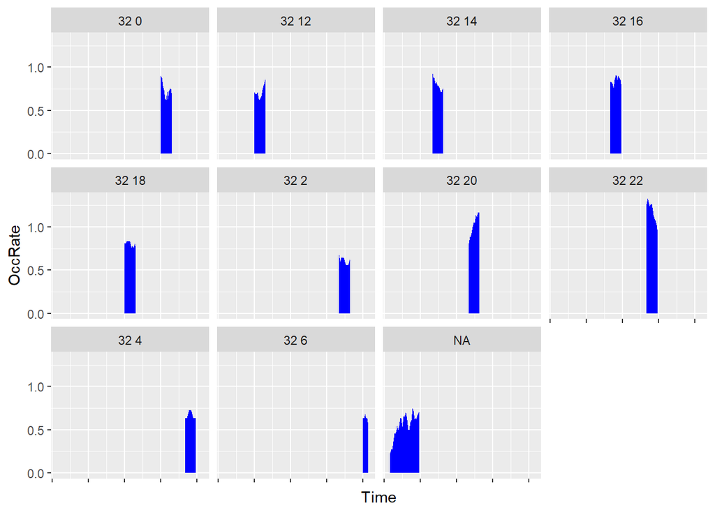

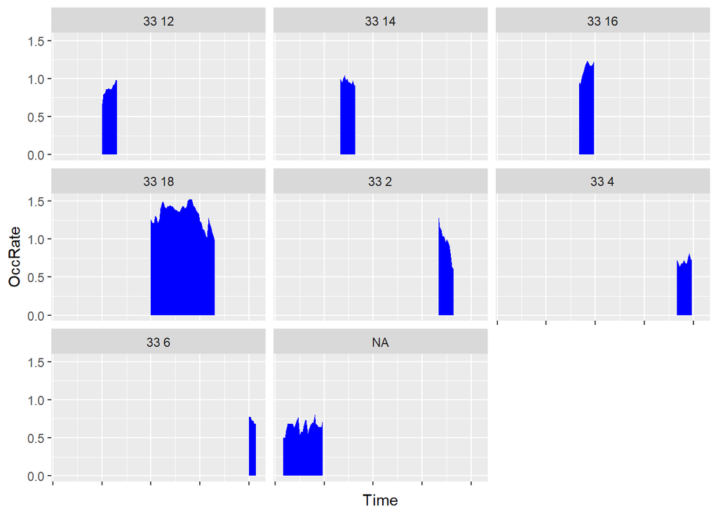

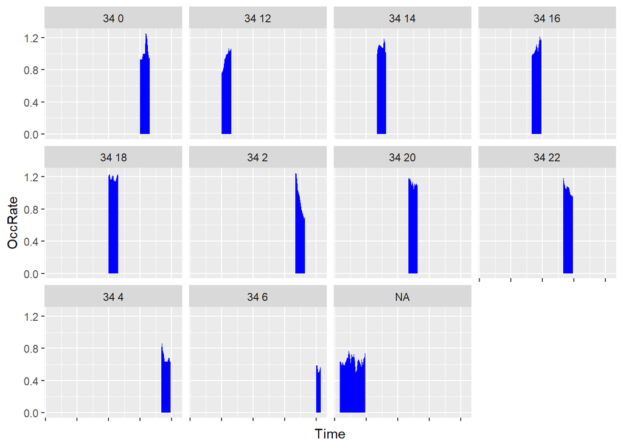

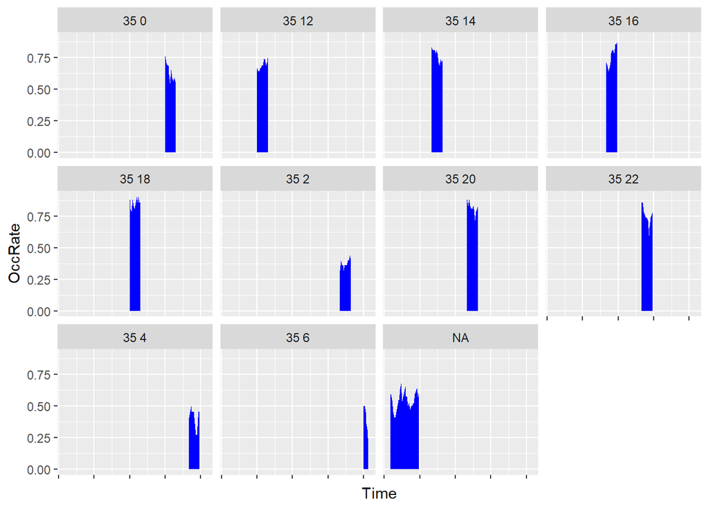

```r
blockplots[29:35]
```

## Appendix: Forecast 12+, Select Plots

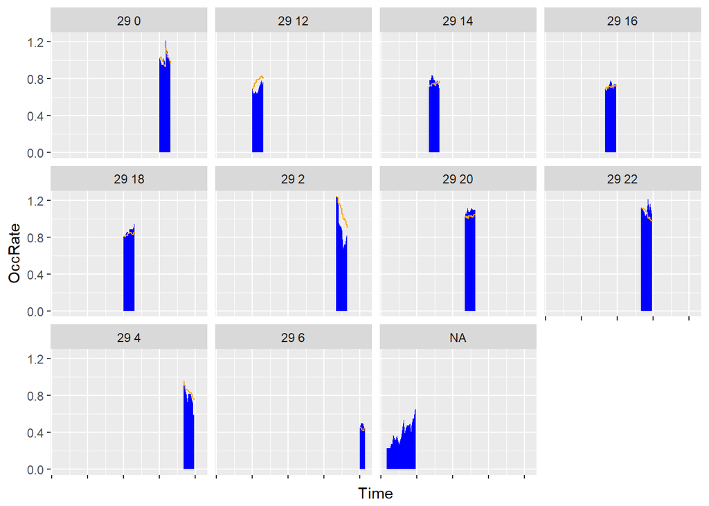

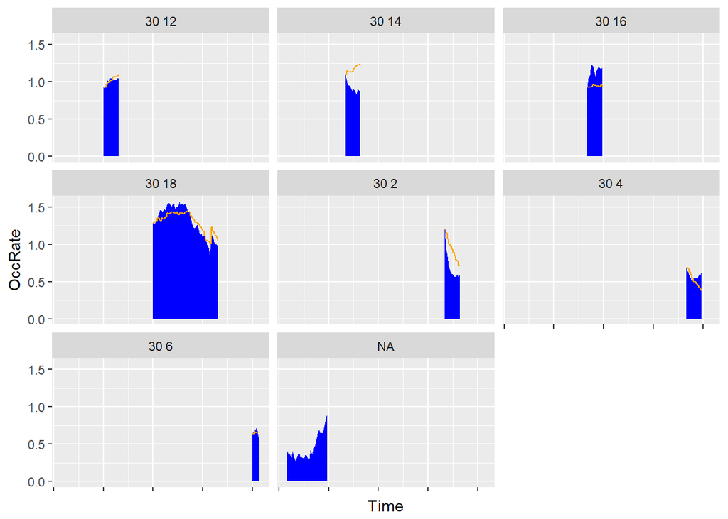

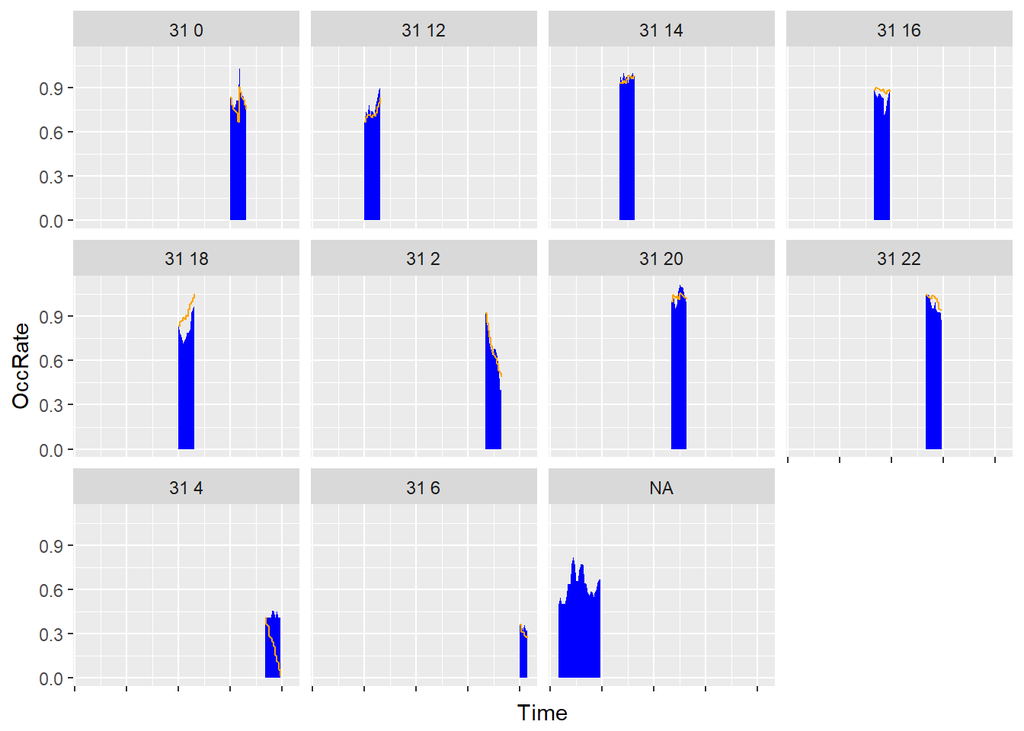

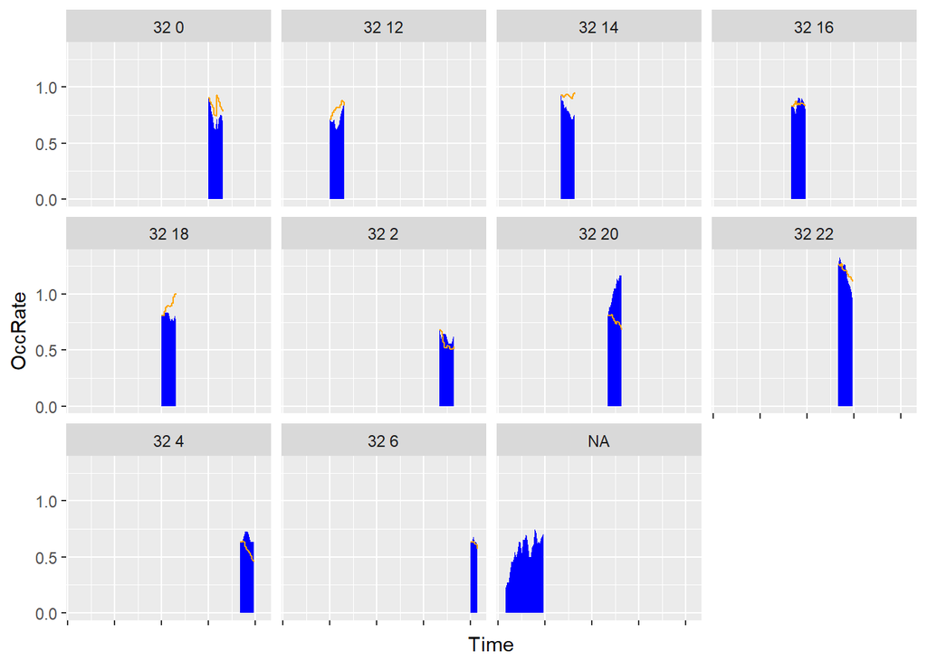

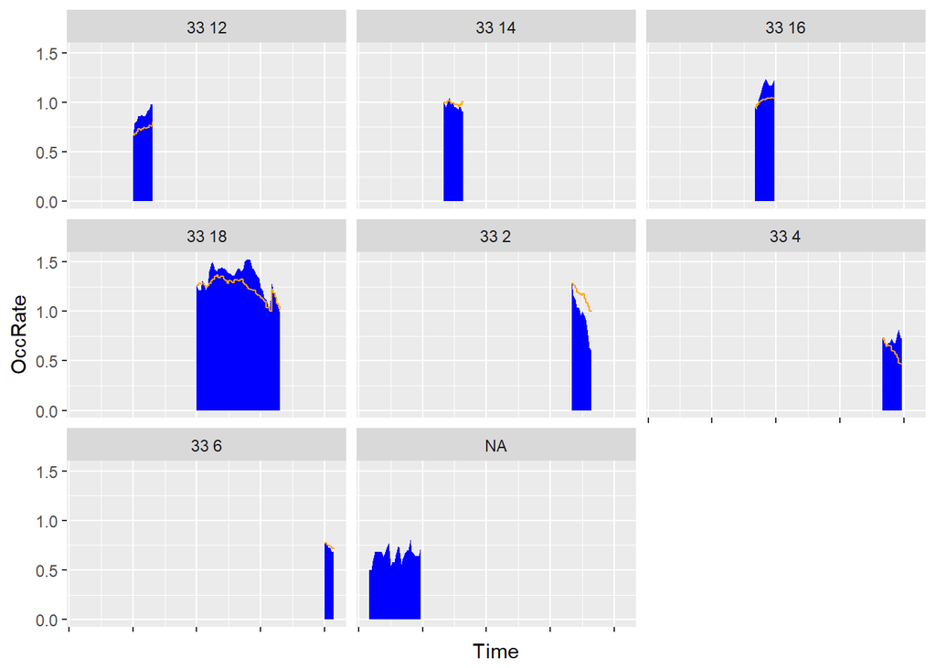

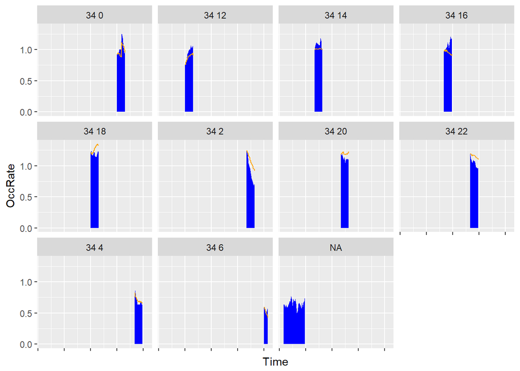

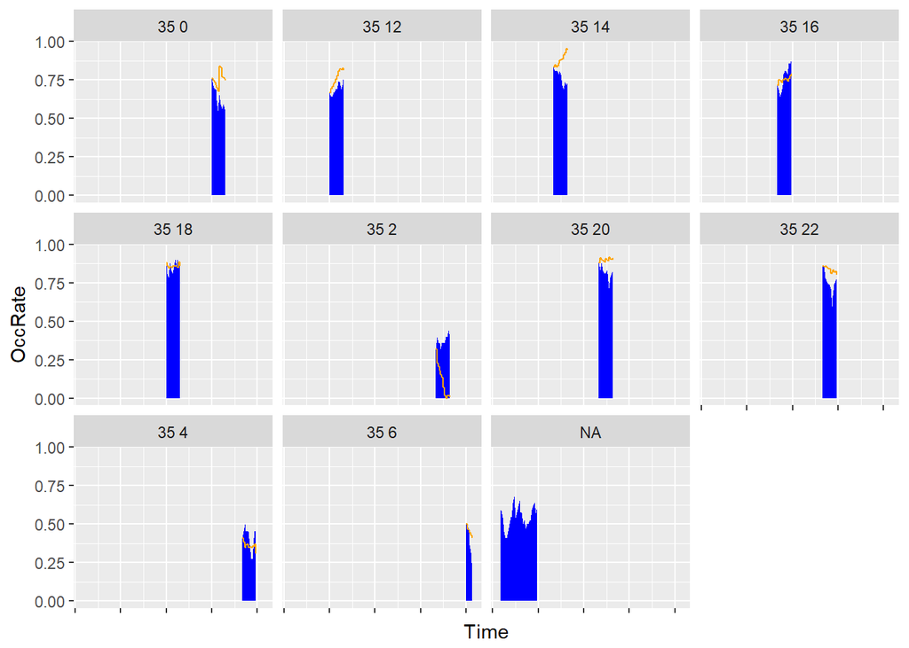

```r
plots12[29:35]
```